# The Markdown File

Loading and Preprocessing the data

```r
require(lubridate)
activitydata <- read.csv("C:/Big Data and Hadoop/R/R Tutorial/course5 assignments1/activity.csv", stringsAsFactors = FALSE)
summary(activitydata)
```

```
##      steps            date              interval
##  Min.   :  0.00   Length:17568       Min.   :   0.0
##  1st Qu.:  0.00   Class :character   1st Qu.: 588.8
##  Median :  0.00   Mode  :character   Median :1177.5
##  Mean   : 37.38                      Mean   :1177.5
##  3rd Qu.: 12.00                      3rd Qu.:1766.2
##  Max.   :806.00                      Max.   :2355.0
##  NA's   :2304
```

```r
activitydata$date<- ymd(activitydata$date)
```

Mean total number of steps taken per day Calculate the total number of steps taken per day A histogram of the total number of steps taken each day Calculate and report the mean and median of the total number of steps taken per day

```r
StepsbyDay<-tapply(activitydata$steps[!is.na(activitydata$steps)],
              activitydata$date[!is.na(activitydata$steps)],sum)

StepsbyDay
```

```
## 2012-10-02 2012-10-03 2012-10-04 2012-10-05 2012-10-06 2012-10-07
##        126      11352      12116      13294      15420      11015
## 2012-10-09 2012-10-10 2012-10-11 2012-10-12 2012-10-13 2012-10-14
##      12811       9900      10304      17382      12426      15098
## 2012-10-15 2012-10-16 2012-10-17 2012-10-18 2012-10-19 2012-10-20
##      10139      15084      13452      10056      11829      10395
## 2012-10-21 2012-10-22 2012-10-23 2012-10-24 2012-10-25 2012-10-26
##       8821      13460       8918       8355       2492       6778
## 2012-10-27 2012-10-28 2012-10-29 2012-10-30 2012-10-31 2012-11-02
##      10119      11458       5018       9819      15414      10600
## 2012-11-03 2012-11-05 2012-11-06 2012-11-07 2012-11-08 2012-11-11
##      10571      10439       8334      12883       3219      12608
## 2012-11-12 2012-11-13 2012-11-15 2012-11-16 2012-11-17 2012-11-18
##      10765       7336         41       5441      14339      15110
## 2012-11-19 2012-11-20 2012-11-21 2012-11-22 2012-11-23 2012-11-24
##       8841       4472      12787      20427      21194      14478
## 2012-11-25 2012-11-26 2012-11-27 2012-11-28 2012-11-29
##      11834      11162      13646      10183       7047
```

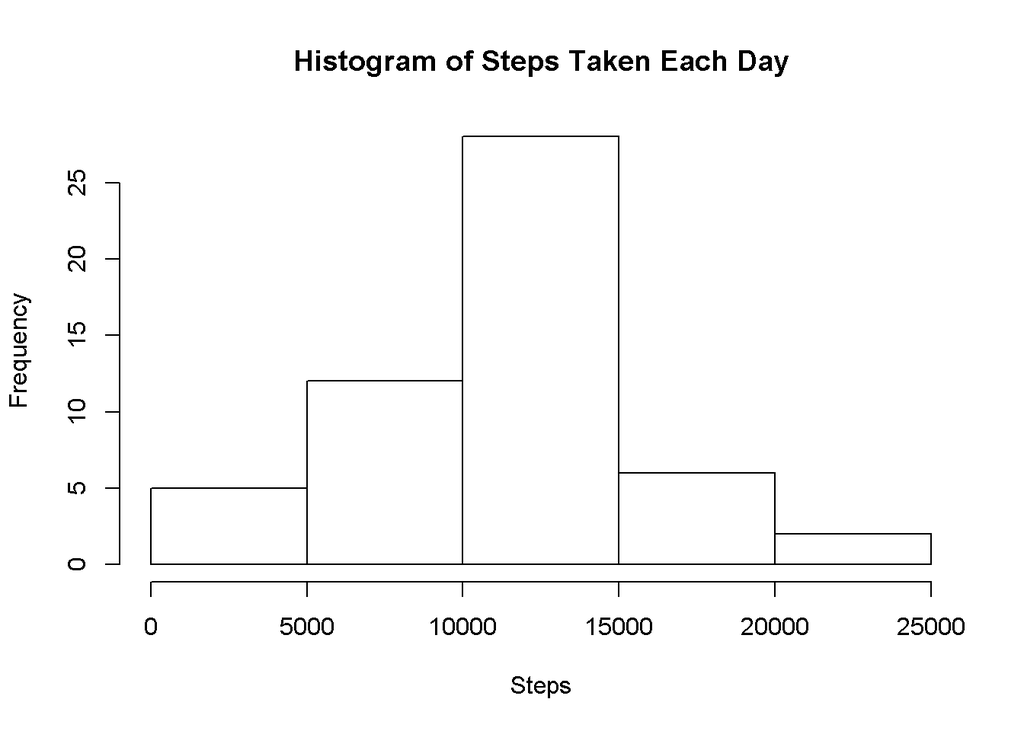

```r
hist(StepsbyDay, main="Histogram of Steps Taken Each Day", xlab="Steps")
```

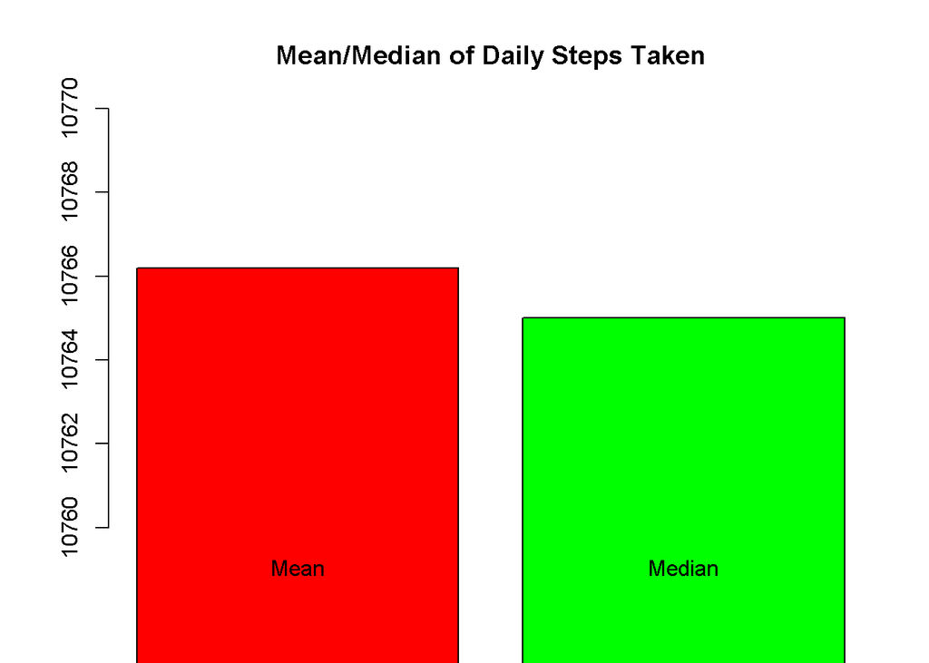

```r
StepsbyDayMean<-mean(StepsbyDay[!is.na(StepsbyDay)])
StepsbyDayMedian<-median(StepsbyDay[!is.na(StepsbyDay)])

barplot(c(StepsbyDayMean,StepsbyDayMedian),
        main="Mean/Median of Daily Steps Taken",col = c("red","green"),
        names.arg=c("Mean","Median"),ylim=c(10760,10770))
```

The average daily activity pattern Time series plot of the 5-minute interval (x-axis) and the average number of steps taken, averaged across all days (y-axis) Which 5-minute interval, on average across all the days in the dataset, contains the maximum number of steps?

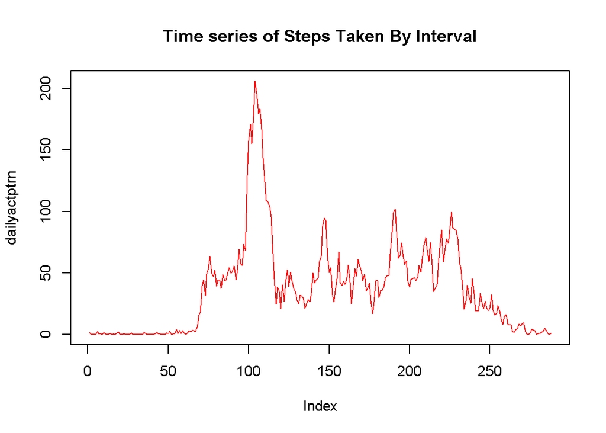

```r
dailyactptrn<-tapply(activitydata$steps[!is.na(activitydata$steps)],
                   activitydata$interval[!is.na(activitydata$steps)],mean)

par(mfrow=c(1,1))
plot(dailyactptrn, main="Time series of Steps Taken By Interval",type = "l",col="red")
```

```r
maxInterval=data.frame(dailyactptrn[dailyactptrn==max(dailyactptrn)])
maxInterval
```

```
##     dailyactptrn.dailyactptrn....max.dailyactptrn..
## 835                                        206.1698
```

Imputing missing values There are a number of days/intervals where there are missing values (coded as NA). The presence of missing days may introduce bias into some calculations or summaries of the data. Calculate and report the total number of missing values in the dataset (i.e. the total number of rows with NAs) A new dataset that is equal to the original dataset but with the missing data filled in. Histogram of the total number of steps taken each day and Calculate and report the mean and median total number of steps taken per day.

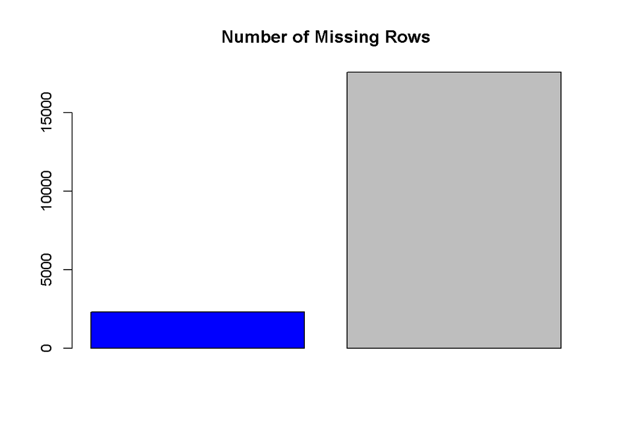

```r
intervalNames<-data.frame(rownames(data.frame(dailyactptrn)))
colnames(intervalNames)<-"interval"

IntervalAverages<-data.frame(c(data.frame(rownames(data.frame(dailyactptrn))),
                               data.frame(dailyactptrn)))
colnames(IntervalAverages)<-c("interval","Average_Interval_Steps")

RowsAll=length(activitydata$steps)
RowsNA=length(activitydata$steps[is.na(activitydata$steps)])

par(mfrow=c(1,1))
barplot(c(RowsNA,RowsAll), main="Number of Missing Rows",col = c("blue","grey"))
```

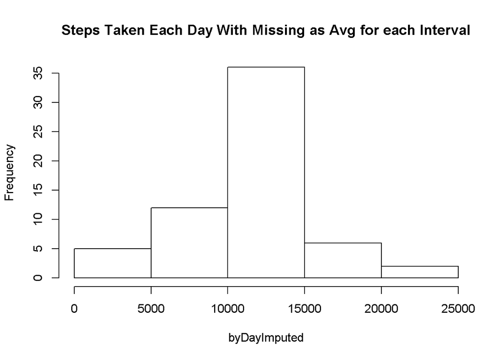

```r
ActivityDataImputed <- merge(activitydata,IntervalAverages,by="interval")

ActivityDataImputed[is.na(ActivityDataImputed$steps),]$steps <-ActivityDataImputed[is.na(ActivityDataImputed$steps),]$Average_Interval_Steps

byDayImputed<-tapply(ActivityDataImputed$steps,ActivityDataImputed$date,sum)
hist(byDayImputed, main="Steps Taken Each Day With Missing as Avg for each Interval")
```

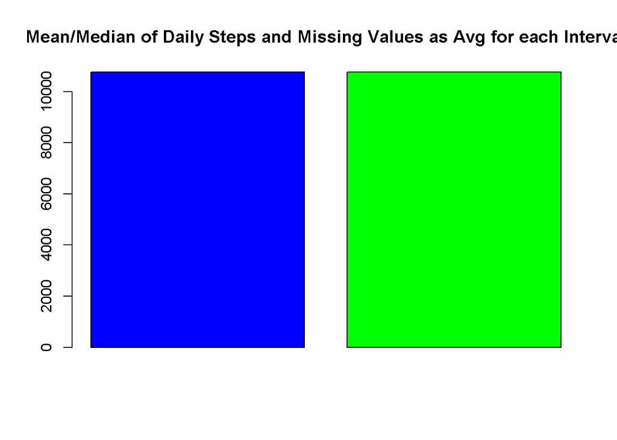

```r
byDayMeanImputed<-mean(byDayImputed[!is.na(StepsbyDay)])
byDayMedianImputed<-median(byDayImputed[!is.na(StepsbyDay)])

par(mfrow=c(1,1))
barplot(c(byDayMeanImputed,byDayMedianImputed),
        main="Mean/Median of Daily Steps and Missing Values as Avg for each Interval",col = c("blue", "green"))
```

```r
ActivityDataImputed$weekdayInd<-with(ActivityDataImputed, !(weekdays(as.Date(ActivityDataImputed$date))=="Saturday" | weekdays(as.Date(ActivityDataImputed$date))=="Sunday"))
```

Are there differences in activity patterns between weekdays and weekends A new factor variable in the dataset with two levels - “weekday” and “weekend” indicating whether a given date is a weekday or weekend day. A panel plot containing a time series plot of the 5-minute interval and the average number of steps taken, averaged across all weekday days or weekend days.

```r
ActivityDataImputed$TimePeriod[ActivityDataImputed$weekdayInd==0]<-"Weekend"
ActivityDataImputed$TimePeriod[ActivityDataImputed$weekdayInd==1]<-"Weekday"

library(dplyr)
```

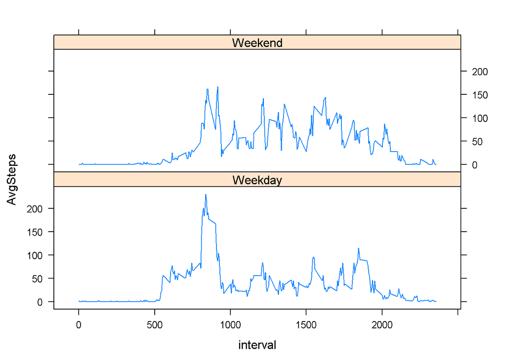

```r
ActivityDataImputed.grpdata <- group_by(ActivityDataImputed, TimePeriod,interval)
ActivityDataImputed.grpdata<-summarize(ActivityDataImputed.grpdata, AvgSteps = mean(steps, na.rm = TRUE))

library(lattice)
xyplot(AvgSteps ~ interval | TimePeriod, data = ActivityDataImputed.grpdata,
        layout = c(1, 2),type = "l")
```